# Exercício Aula 1 - Análise de Sobrevivência

Vinícius de Souza Maia

01/05/2020

```r
# Pacotes
library(tidyverse)
library(survival)
library(patchwork)

# Definição de algumas funções que serão usadas ao longo do exercício
# Trajetória do grupo
grup_traj <- function(data, tempo = tempo, id = id) {
  require(ggplot2)
  require(dplyr)
  data <- mutate(data, status2 = recode(status, `1` = 4, `0` = 1))
  y_breaks <- length(data$id)
  x_breaks <- max(data$tempo)

  ggplot(data) +
    geom_point(aes(tempo, id, shape = status2), size = 3) +
    geom_segment(aes(x = 0, y = id, xend = tempo, yend = id)) +
    scale_x_continuous(breaks = scales::extended_breaks(x_breaks),
                       name = "Meses") +
    scale_y_continuous(breaks = scales::extended_breaks(y_breaks),
                       name = "Paciente") +
    scale_shape_identity() +
    theme(panel.grid.minor = element_blank(),
          panel.grid.major = element_blank()) +
    coord_cartesian(xlim = c(0.25, x_breaks + 0.5))
}


# Trajetória do indivíduo
indiv_traj <- function(data, i) {
  require(ggplot2)
  require(patchwork)

  tmax  <- max(data$tempo.fim)
  t.ini <- data$tempo.ini[[i]]
  t.fim <- data$tempo.fim[[i]]
  censu <- data$status[[i]]

  individuo_n <- tibble(
    tempo2 = seq(0, tmax + 1, 1),
    Yx = ifelse(tempo2 >= t.ini & tempo2 < t.fim, 1, 0),
    Nx = ifelse(tempo2 >= t.fim & t.fim != tmax, 1, 0),
    status = data$status[[i]])

  pontos.Nx <- tibble(
    x = with(individuo_n, ifelse(Nx != lag(Nx), tempo2, NA_integer_)),
    y = with(individuo_n, ifelse(Nx != lag(Nx), 1, NA_integer_)),
    shape = ifelse(data$status[[i]] == 0 & x == data$tempo.fim[[i]], 1, 16))

  pontos.Yx <- tibble(
    x = with(individuo_n, ifelse(Yx != lag(Yx), tempo2, NA_integer_)),
    y = with(individuo_n, ifelse(Yx != lag(Yx), lag(Yx), NA_integer_)),
    shape = ifelse(data$status[[i]] == 0 & x == data$tempo.fim[[i]], 1, 16))

  g <- ggplot(individuo_n) +
    geom_step(aes(tempo2, Nx), direction = "hv", na.rm = TRUE) +
    geom_point(data = pontos.Nx,
               aes(x, y, shape = shape),
               size = 3,
               na.rm = TRUE) +
    scale_shape_identity() +
    scale_x_continuous(breaks = seq(0, tmax, 2),
                       minor_breaks = NULL,
                       limits = c(0, tmax),
                       name = "Meses") +
    scale_y_continuous(breaks = 0:1,
                       limits = c(-1, 2),
                       minor_breaks = NULL,
                       name = expression(N[i](x))) +
    theme_classic() +
    theme(panel.grid = element_blank())

  h <- ggplot(individuo_n) +
    geom_step(aes(tempo2, Yx), direction = "hv", na.rm = TRUE) +
    geom_point(
      data = pontos.Yx,
      aes(x, y, shape = shape),
      size = 3,
      na.rm = TRUE) +
    scale_shape_identity() +
    scale_x_continuous(limits = c(0, tmax), minor_breaks = NULL) +
    scale_y_continuous(
      breaks = 0:1,
      limits = c(-1, 2),
      minor_breaks = NULL,
      name = expression(Y[i](x))) +
    theme_classic() +
    theme(
      axis.title.x = element_blank(),
      axis.text.x = element_blank(),
      axis.ticks.x = element_blank(),
      panel.grid = element_blank()) +
    ggtitle(paste0("Paciente ", i))

  wrap_plots(h, g, nrow = 2)
}
```

## Exercício 2.1

O tempo de aleitamento, isto é, o tempo decorrido desde o nascimento até o desmame, pode ser considerado uma variável tempo de sobrevivência. Suponha que o tempo até o desmame em meses tenha sido registrado para 15 crianças que nasceram no mesmo dia:

```
6 12 10 3 5 1 6 8 1 5 2 2 5 8 1
```

Considerando que não houve censura:

1. Represente graficamente os tempos de observação

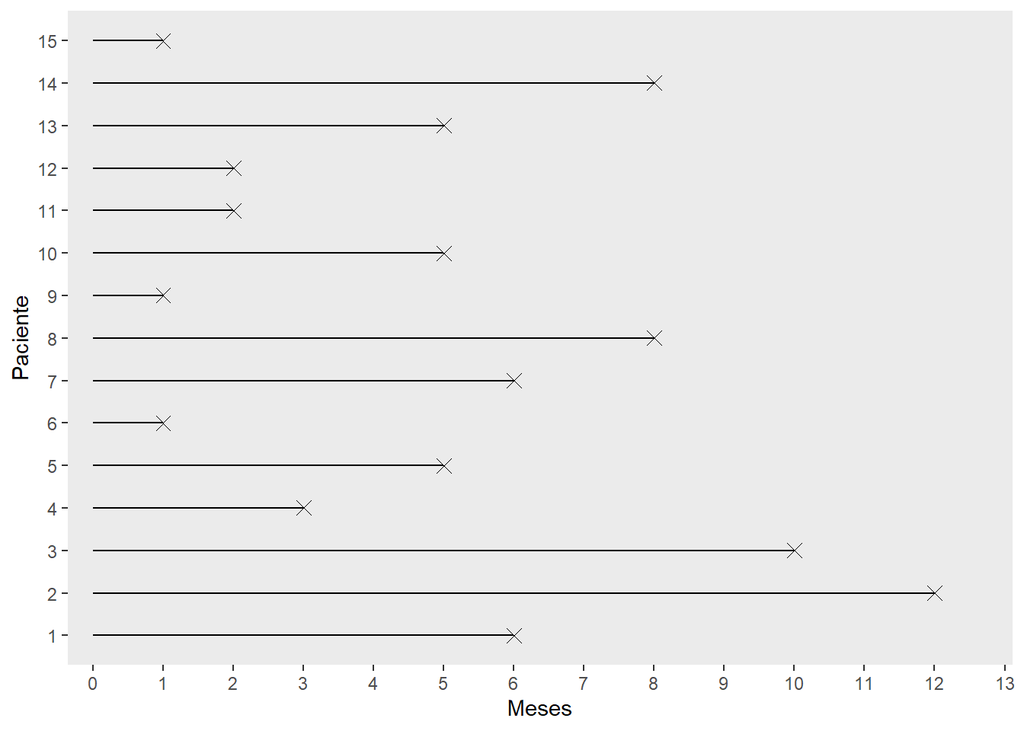

```r
aleit <- tibble(id     = 1:15,
                tempo  = c(6, 12, 10, 3, 5, 1, 6, 8, 1, 5, 2, 2, 5, 8, 1),
                status = 1)

grup_traj(aleit)
```

2. Represente as trajetórias dos primeiros cinco indivíduos utilizando as variáveis N(t) e Y(t)

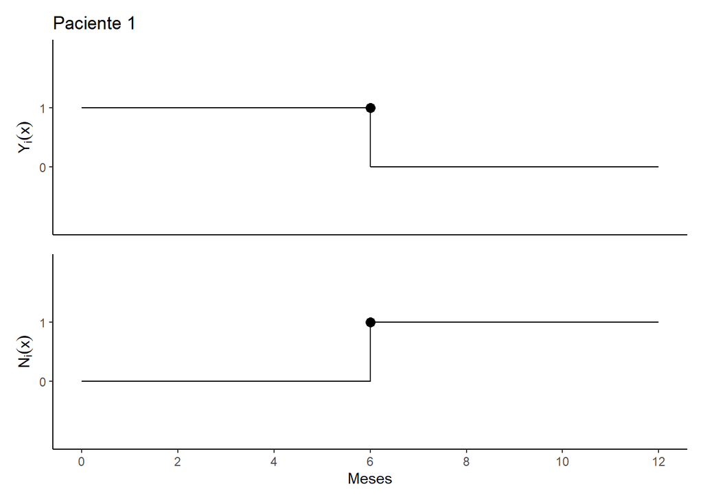

```r
aleit_cont <- mutate(aleit,
                     tempo.ini = 0L,
                     tempo.fim = as.integer(tempo),
                     tempo = tempo.fim - tempo.ini,
                     status = 1L)

indiv_traj(aleit_cont, 1)
```

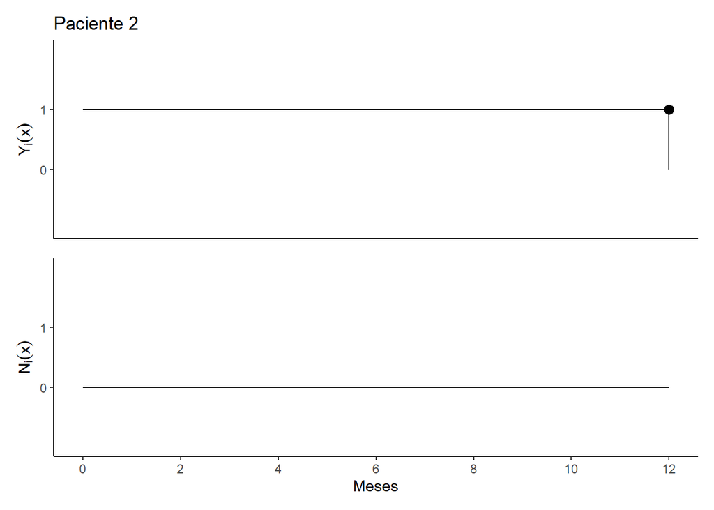

```r
indiv_traj(aleit_cont, 2)
```

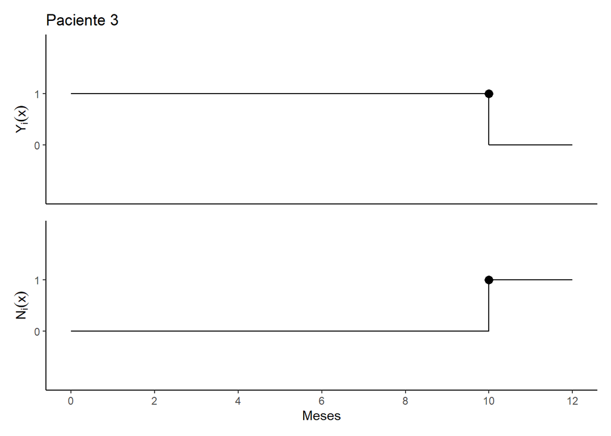

```r
indiv_traj(aleit_cont, 3)
```

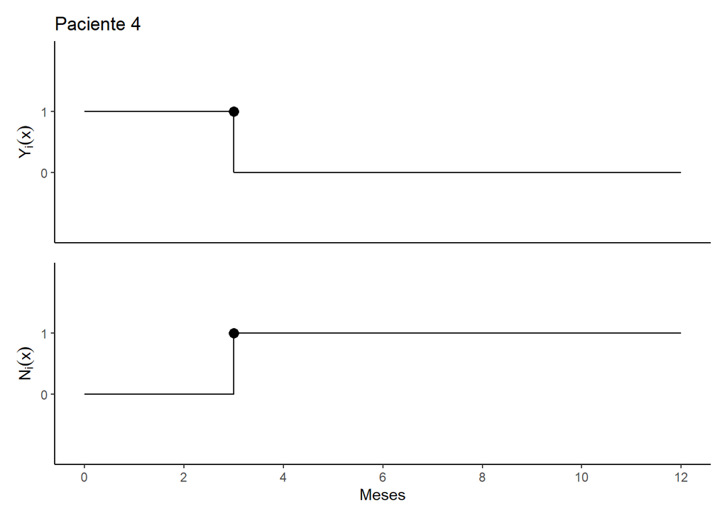

```r
indiv_traj(aleit_cont, 4)
```

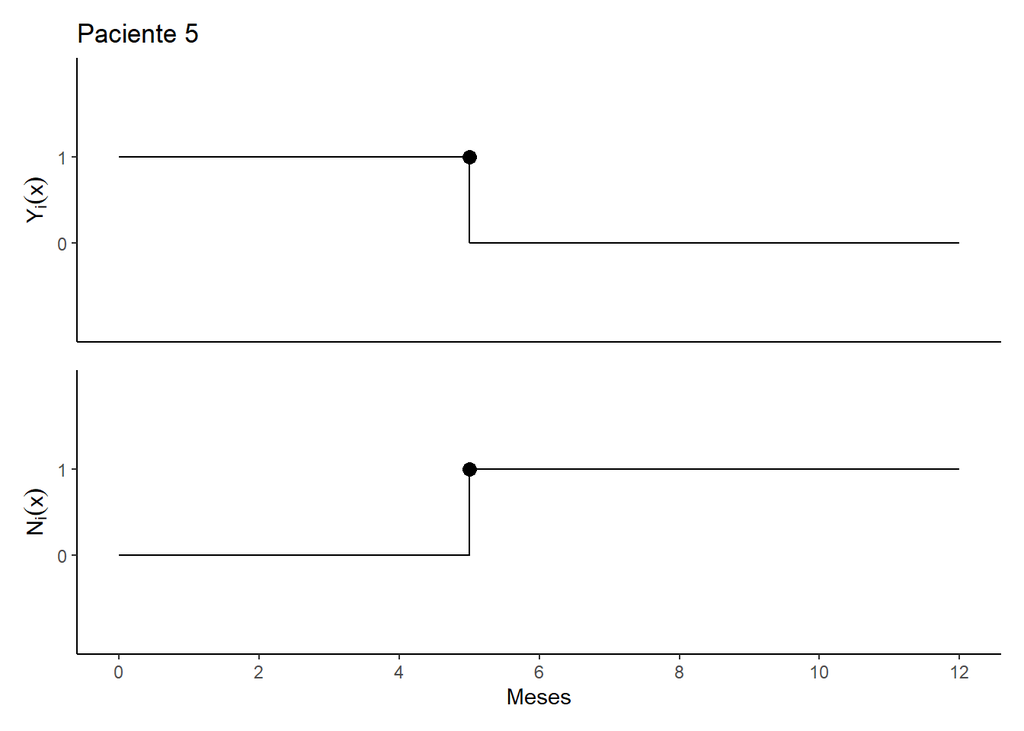

```r
indiv_traj(aleit_cont, 5)
```

3. Como você construiria um banco de dados para analisar esses dados pelo processo clássico?

```r
aleit
```

```
## # A tibble: 15 x 3
##       id tempo status
##    <int> <dbl>  <dbl>
##  1     1     6      1
##  2     2    12      1
##  3     3    10      1
##  4     4     3      1
##  5     5     5      1
##  6     6     1      1
##  7     7     6      1
##  8     8     8      1
##  9     9     1      1
## 10    10     5      1
## 11    11     2      1
## 12    12     2      1
## 13    13     5      1
## 14    14     8      1
## 15    15     1      1
```

4. E pelo processo de contagem?

```r
aleit_cont
```

```
## # A tibble: 15 x 5
##       id tempo status tempo.ini tempo.fim
##    <int> <int>  <int>     <int>     <int>
##  1     1     6      1         0         6
##  2     2    12      1         0        12
##  3     3    10      1         0        10
##  4     4     3      1         0         3
##  5     5     5      1         0         5
##  6     6     1      1         0         1
##  7     7     6      1         0         6
##  8     8     8      1         0         8
##  9     9     1      1         0         1
## 10    10     5      1         0         5
## 11    11     2      1         0         2
## 12    12     2      1         0         2
## 13    13     5      1         0         5
## 14    14     8      1         0         8
## 15    15     1      1         0         1
```

## Exercício 2.2

Considere agora o tempo de sobrevivência de 15 pacientes submetidos à hemodiálise. Neste caso, a variável de interesse é o tempo desde a primeira diálise até o óbito (em meses).

```
2 4 29+ 6+ 3 1 1 2 3 9+ 10 11 5+ 5 1
```

Os tempos censurados estão indicados pelo sinal de +. Considere que todos os pacientes entraram juntos no início do estudo.

1. Represente graficamente os tempos de observação dos pacientes utilizando a notação clássica.

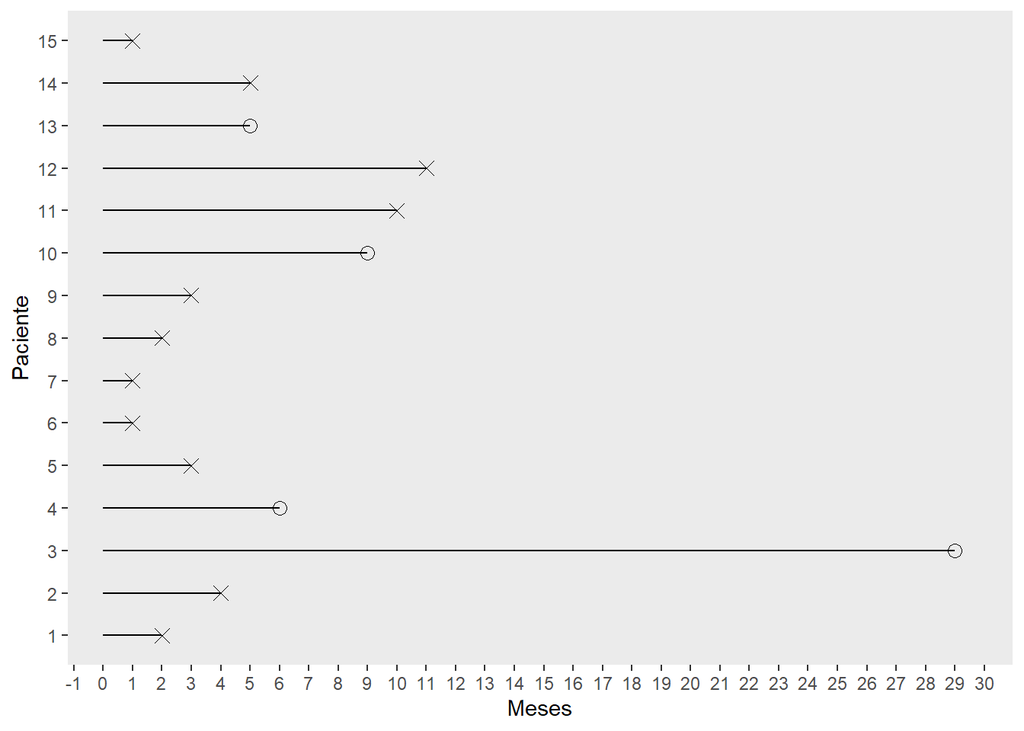

```r
dial <- tibble(
  id     = 1:15,
  tempo  = c(2L, 4L, 29L, 6L, 3L, 1L, 1L, 2L, 3L, 9L, 10L, 11L, 5L, 5L, 1L),
  status = c(1, 1, 0, 0, 1, 1, 1, 1, 1, 0, 1, 1, 0, 1, 1))

grup_traj(dial)
```

2. Represente as trajetórias dos primeiros cinco indivíduos utilizando as variáveis *N(t)* e *Y(t)* do processo de contagem.

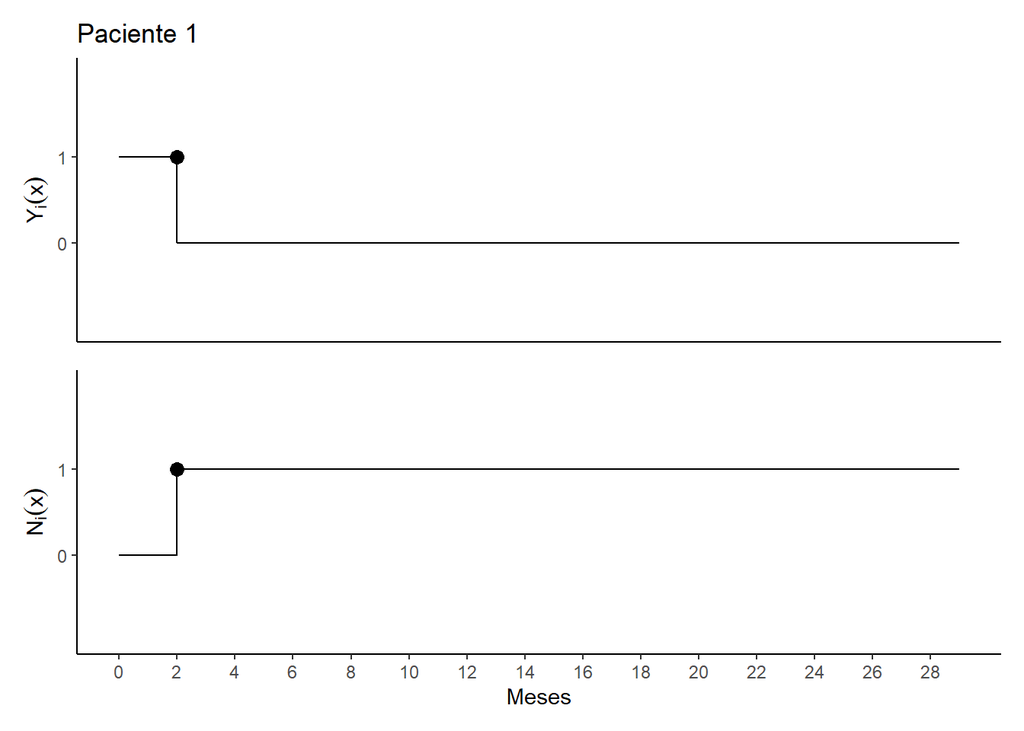

```r
dial_cont <- cbind(dial, tempo.fim = dial$tempo, tempo.ini = 0)

indiv_traj(dial_cont, 1)
```

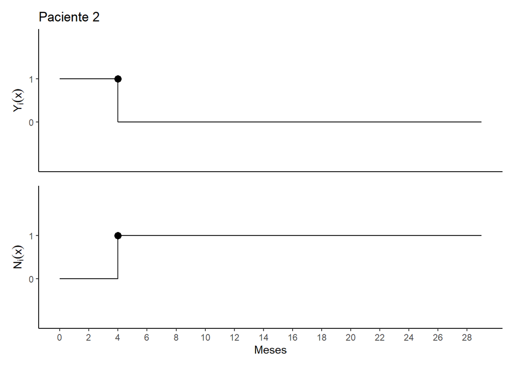

```r
indiv_traj(dial_cont, 2)
```

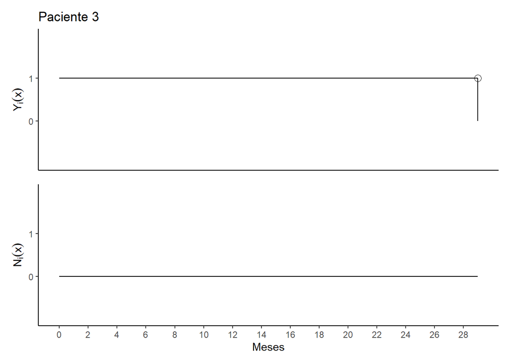

```r
indiv_traj(dial_cont, 3)
```

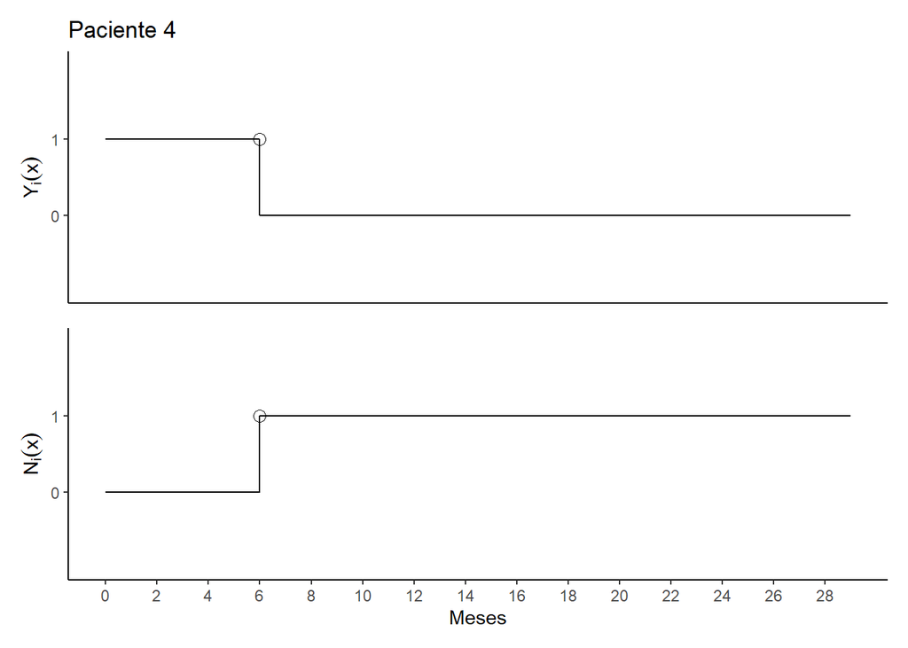

```r
indiv_traj(dial_cont, 4)
```

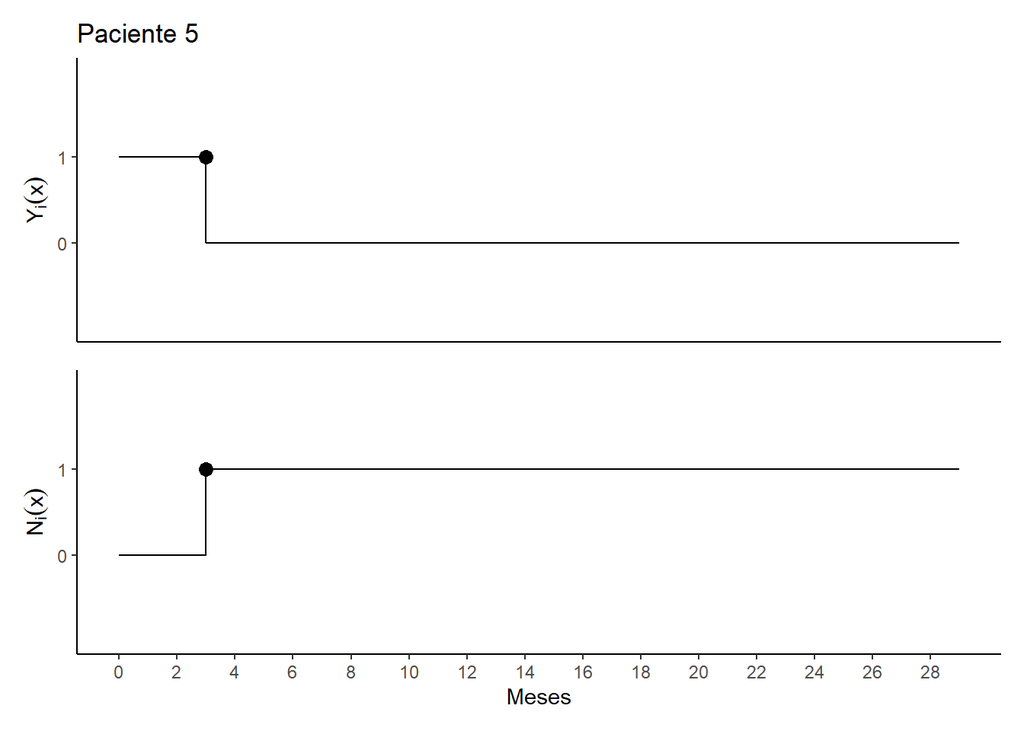

```r
indiv_traj(dial_cont, 5)
```

3. Construa um banco de dados para analisar esses dados pelo processo clássico.

```r
dial
```

```
## # A tibble: 15 x 3
##       id tempo status
##    <int> <int>  <dbl>
##  1     1     2      1
##  2     2     4      1
##  3     3    29      0
##  4     4     6      0
##  5     5     3      1
##  6     6     1      1
##  7     7     1      1
##  8     8     2      1
##  9     9     3      1
## 10    10     9      0
## 11    11    10      1
## 12    12    11      1
## 13    13     5      0
## 14    14     5      1
## 15    15     1      1
```

4. Reconstrua o banco de dados, na forma de processo de contagem, considerando que essa é uma coorte aberta e as datas de início do tempo de observação de cada paciente são dadas pela tabela abaixo.

```r
dial_cont <- tibble(
  id        = 1:15,
  tempo.ini = c(0, 1, 12, 3, 1, 7, 0, 1, 1, 3, 12, 4, 4, 1, 22),
  tempo     = c(2L, 4L, 29L, 6L, 3L, 1L, 1L, 2L, 3L, 9L, 10L, 11L, 5L, 5L, 1L),
  tempo.fim = tempo + tempo.ini,
  status    = c(1, 1, 0, 0, 1, 1, 1, 1, 1, 0, 1, 1, 0, 1, 1)
)

dial_cont
```

```
## # A tibble: 15 x 5
##       id tempo.ini tempo tempo.fim status
##    <int>     <dbl> <int>     <dbl>  <dbl>
##  1     1         0     2         2      1
##  2     2         1     4         5      1
##  3     3        12    29        41      0
##  4     4         3     6         9      0
##  5     5         1     3         4      1
##  6     6         7     1         8      1
##  7     7         0     1         1      1
##  8     8         1     2         3      1
##  9     9         1     3         4      1
## 10    10         3     9        12      0
## 11    11        12    10        22      1
## 12    12         4    11        15      1
## 13    13         4     5         9      0
## 14    14         1     5         6      1
## 15    15        22     1        23      1
```

## Exercício 2.3

Em um hospital, seis pacientes HIV positivo são acompanhados ao longo de um ano. No gráfico a seguir, as linhas horizontais representam o tempo de acompanhamento de cada paciente: linhas terminadas em “X” indicam a ocorrência do desfecho (óbito), linhas terminadas em com “o” indicam censuras. Represente, utilizando as variáveis *N(t)* e *Y(t)*, as trajetórias de cada um dos seis pacientes.

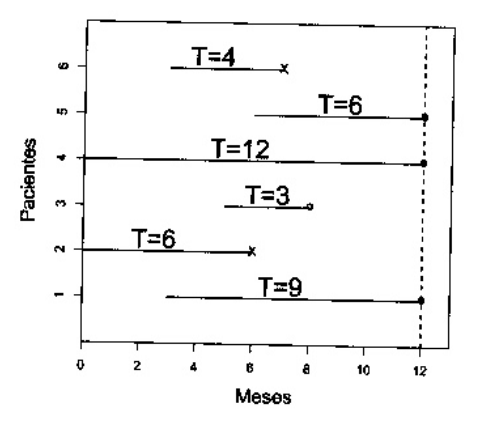

Gráfico

```r
aids <- tibble(id = 1:6,
               tempo = c(4, 6, 12, 3, 6, 9),
               tempo.ini = c(3, 6, 0, 5, 0, 3),
               tempo.fim = tempo + tempo.ini,
               status = c(1, 0, 0, 0, 1, 0))
aids
```

```
## # A tibble: 6 x 5
##      id tempo tempo.ini tempo.fim status
##   <int> <dbl>     <dbl>     <dbl>  <dbl>
## 1     1     4         3         7      1
## 2     2     6         6        12      0
## 3     3    12         0        12      0
## 4     4     3         5         8      0
## 5     5     6         0         6      1
## 6     6     9         3        12      0
```

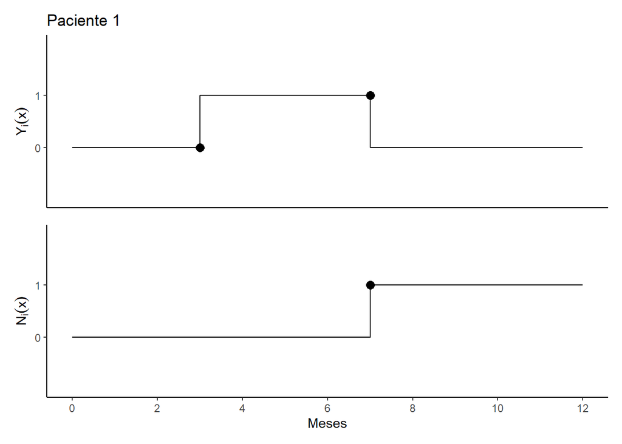

```r
# Trajetórias
indiv_traj(aids, 1)
```

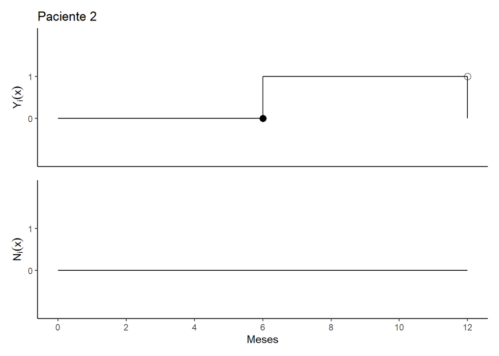

```r
indiv_traj(aids, 2)
```

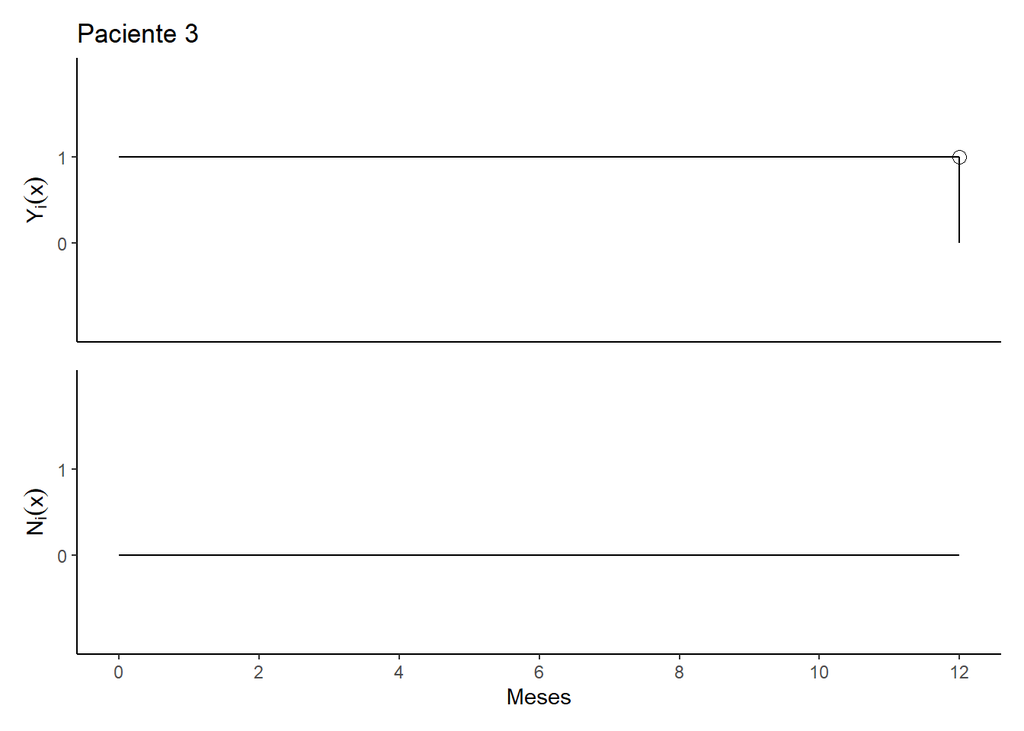

```r
indiv_traj(aids, 3)
```

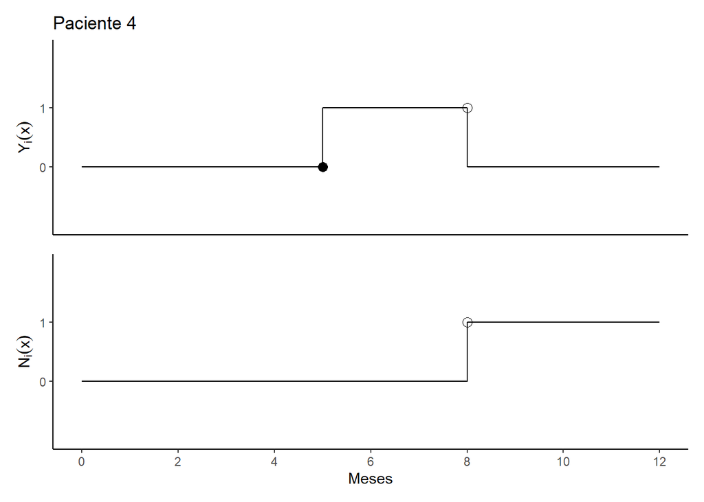

```r
indiv_traj(aids, 4)
```

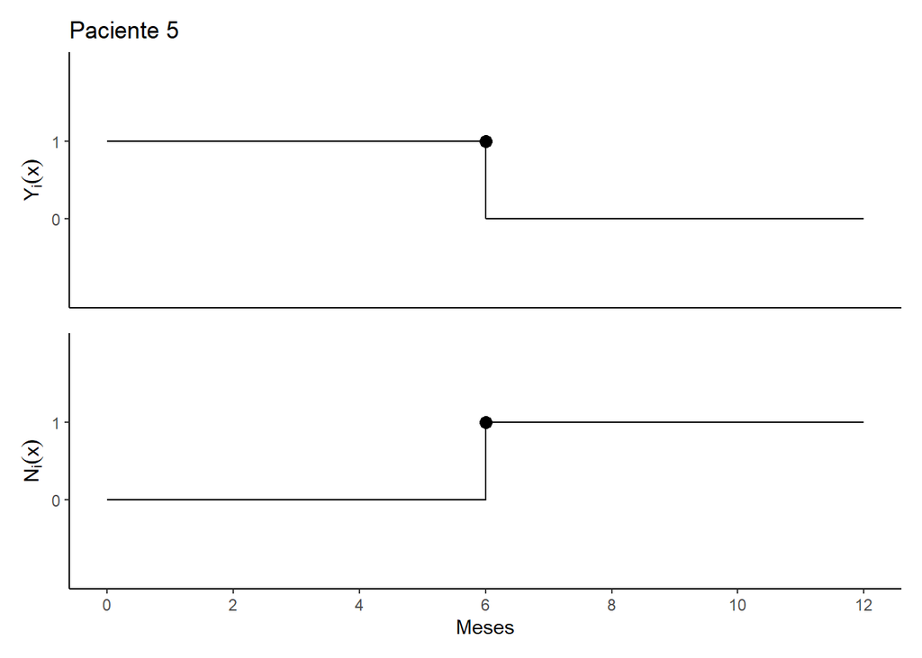

```r
indiv_traj(aids, 5)
```

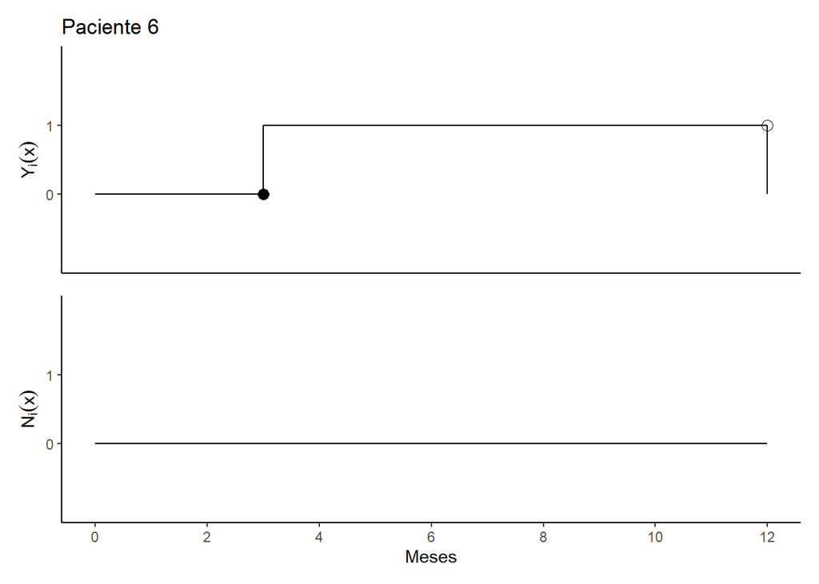

```r
indiv_traj(aids, 6)
```

## Exercício 2.4

Considerando a trajetória observada de um paciente apresentada na figura abaixo, responda:

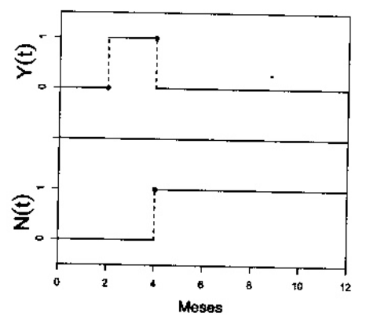

Gráfico

1. Qual foi o mês de entrada do paciente no estudo?

   O paciente entrou no estudo no mês 2.
2. Em que mês ocorreu o desfecho?

   O desfecho ocorreu no mês 4.
3. Em que meses o paciente esteve sob risco de óbito?

   Nos meses 3 e 4.

## Exercício 2.5

Outro paciente tem a seguinte trajetória de observação:

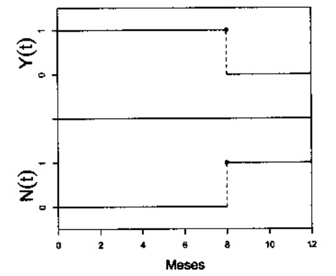

Gráfico

Com base neste gráfico, responda:

1. Qual foi a data de entrada do paciente no estudo?

   O paciente entrou no estudo no início, ou seja, no t = 0.
2. Em que data ocorreu o desfecho?

   O desfecho ocorreu no mês 8.

## Exercício 2.6

1. Construa o banco de dados no formato clássico.

```r
(hiv <- tibble(
  id     = 1:6,
  tempo = c(1, 3, 2, 3, 2, 5),
  status = 1))
```

```
## # A tibble: 6 x 3
##      id tempo status
##   <int> <dbl>  <dbl>
## 1     1     1      1
## 2     2     3      1
## 3     3     2      1
## 4     4     3      1
## 5     5     2      1
## 6     6     5      1
```

2. Construa o banco de dados na forma de processo de contagem.

```r
(hiv_cont <- tibble(id     = 1:6,
                   tempo.ini  = c(0, 0, 1, 3, 2, 2),
                   tempo = c(1, 3, 2, 3, 2, 5),
                   tempo.fim  = tempo.ini + tempo,
                   status = 1))
```

```
## # A tibble: 6 x 5
##      id tempo.ini tempo tempo.fim status
##   <int>     <dbl> <dbl>     <dbl>  <dbl>
## 1     1         0     1         1      1
## 2     2         0     3         3      1
## 3     3         1     2         3      1
## 4     4         3     3         6      1
## 5     5         2     2         4      1
## 6     6         2     5         7      1
```

3. Represente graficamente os tempos observados desses indivíduos.

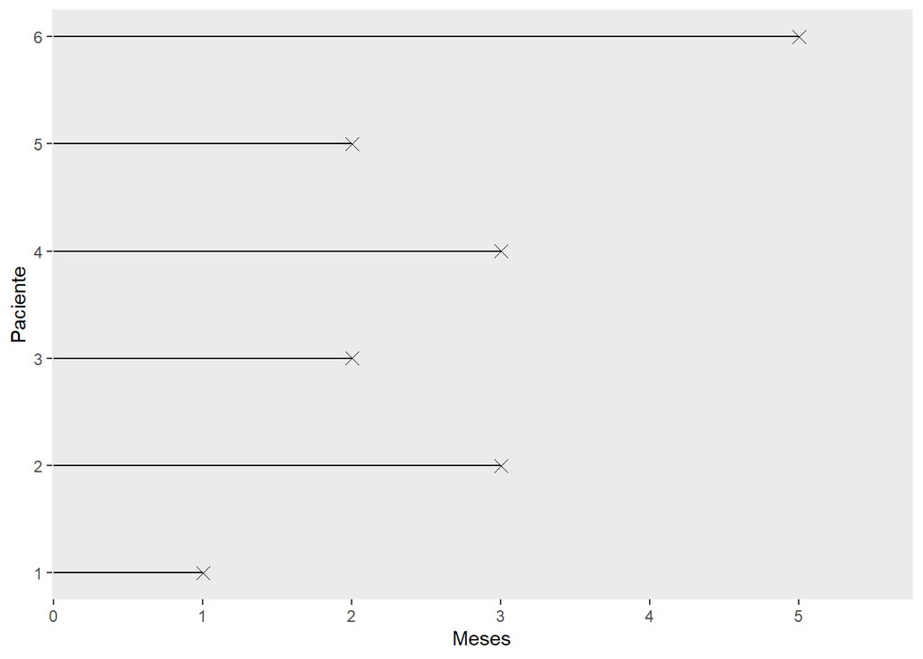

```r
grup_traj(hiv_cont)
```

4. Represente as trajetórias dos 6 indivíduos utilizando *N(t)* e *Y(t)*.

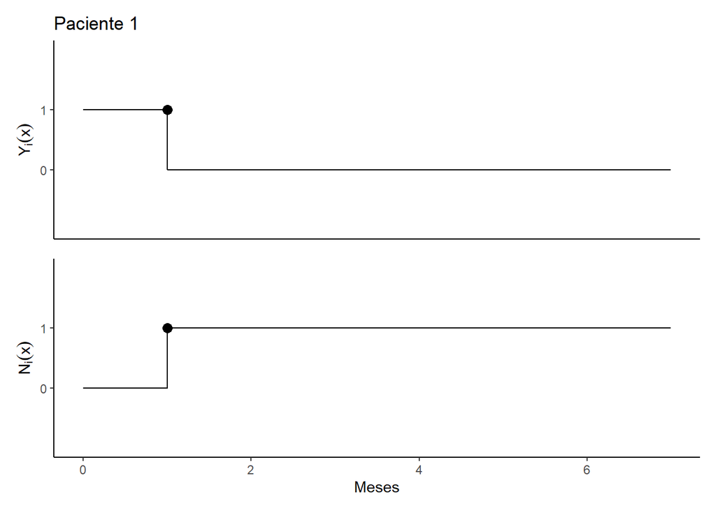

```r
indiv_traj(hiv_cont, 1)
```

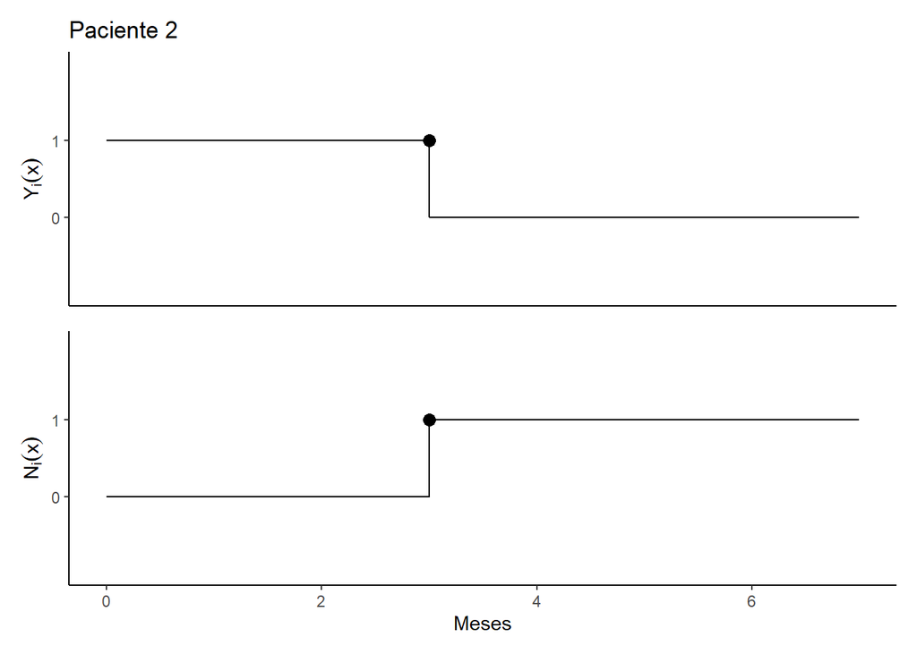

```r
indiv_traj(hiv_cont, 2)
```

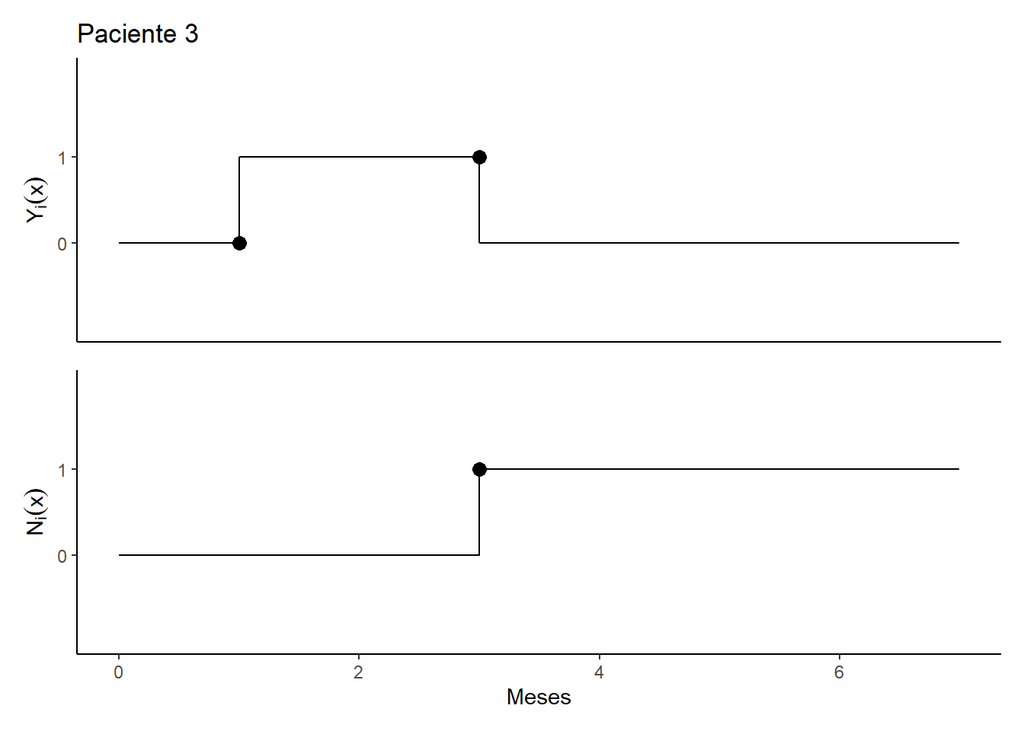

```r
indiv_traj(hiv_cont, 3)
```

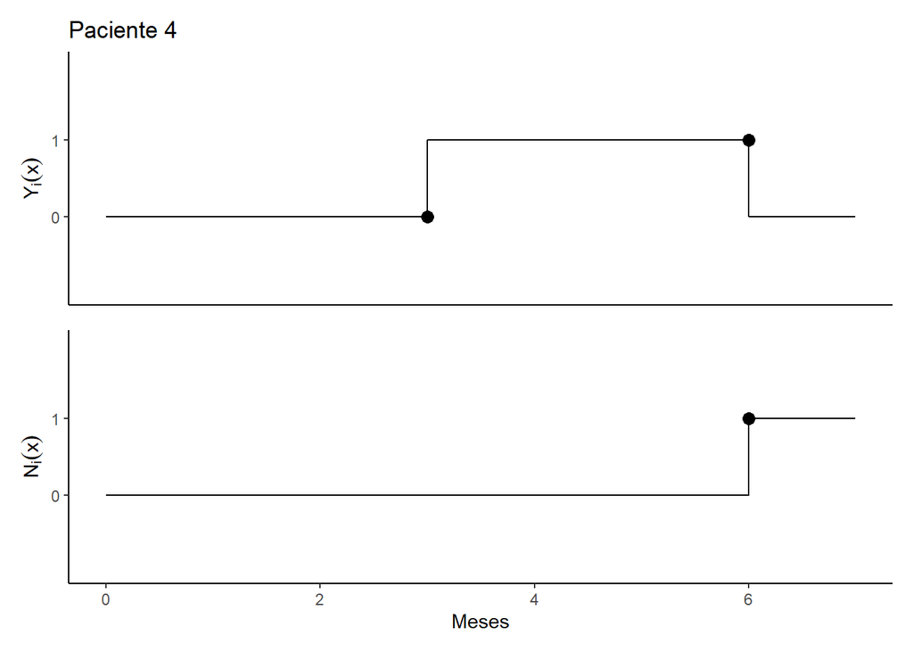

```r
indiv_traj(hiv_cont, 4)
```

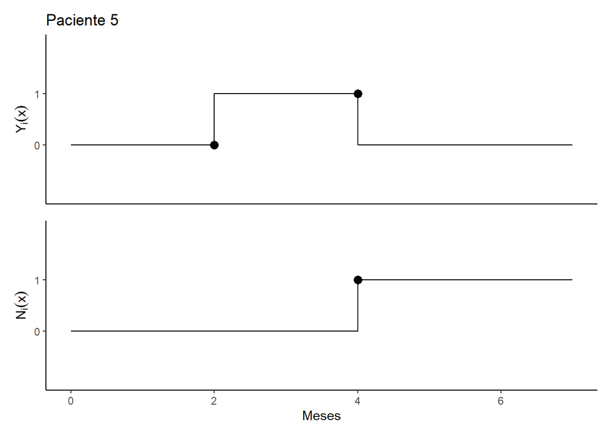

```r
indiv_traj(hiv_cont, 5)
```

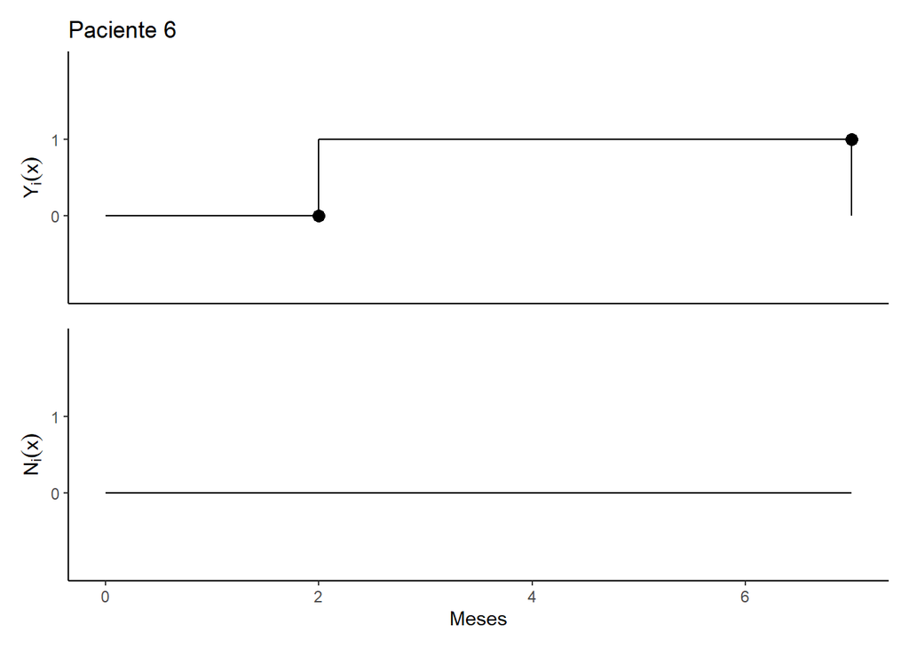

```r
indiv_traj(hiv_cont, 6)
```

5. Quais são os indivíduos em risco no quinto mês de estudo.

```r
filter(hiv_cont, tempo.ini < 5, tempo.fim >= 5)
```

```
## # A tibble: 2 x 5
##      id tempo.ini tempo tempo.fim status
##   <int>     <dbl> <dbl>     <dbl>  <dbl>
## 1     4         3     3         6      1
## 2     6         2     5         7      1
```

6. Que tipo de censura ocorreu neste estudo?

   Censura intervalar.
7. Em que situação ocorreria truncamento?

   Truncamento a esquerda ocorreria no caso de pacientes positivarem no teste inicial, pois eles teriam positivado fora da janela temporal do estudo. Truncamento a direita ocorreria se o estudo analisasse apenas os casos de pacientes que positivaram durante a janela temporal.

## Exercício 2.7

Para se familiarizar com o R e com o banco de dados do Ipec (ipec.csv, veja o Apêndice, seção Aids - clássico) que será utilizado nos próximos capítulos, inicie a análise de sobrevivência observando os dados dos pacientes:

1. No formato clássico.

```r
(ipec <- read_csv2("ipec.csv"))
```

```
## # A tibble: 193 x 15
##       id   ini   fim tempo status sexo  escola idade risco acompan obito
##    <dbl> <dbl> <dbl> <dbl>  <dbl> <chr>  <dbl> <dbl> <dbl>   <dbl> <chr>
##  1     1  1243  2095   852      1 M          3    34     0       1 S
##  2     2  2800  2923   123      1 M          2    38     6       1 S
##  3     3  1250  2395  1145      1 M         NA    32     0       1 S
##  4     4  1915  4670  2755      0 M         NA    43     6       0 N
##  5     5  2653  4770  2117      0 M         NA    40     0       1 N
##  6     6     3   332   329      0 M         NA    34     0       1 I
##  7     7    36    96    60      1 M         NA    27     0       2 S
##  8     8     1   152   151      1 M          0    22     6       2 S
##  9     9   544  2107  1563      1 M          2    44    NA       0 S
## 10    10    71  1318  1247      1 M          2    23     0       2 S
## # ... with 183 more rows, and 4 more variables: anotrat <dbl>,
## #   tratam <dbl>, doenca <dbl>, propcp <dbl>
```

```r
with(ipec, Surv(tempo, status))
```

```
##   [1]  852   123  1145  2755+ 2117+  329+   60   151  1563  1247    84
##  [12]  214    25+ 1348   158   555   408  1116   998  1125   944+   54
##  [23]  151   855   116    80+ 1757+  194   183    37   237+ 1506   168+
##  [34]  134   803+   18   371   173   688   163  3178+   29    50+  887
##  [45]  516   645   310   204  1344+ 1261   285    83   150  1307+ 1076+
##  [56] 1226   865+  811  2898    80   967   618   235  2236+  152   892
##  [67]   81+ 1085  1073+ 1615+   35   290  1780+ 3228+   52   733  3213+
##  [78] 1983  2304+  572    21  1272+ 1646+  304   418   854  2973+   40
##  [89]  850  1139   323  1507+ 2717+ 1735+  388+  145   905   927  1027+
## [100]  631  2495+ 1331+  623  2568+ 2013+  721  1952+  397   254  1630+
## [111] 1523+  146+  108  1835+  499   333   202+ 2437+ 1015  2138+   22
## [122] 2090+  179  2439+ 1063+   85+  343+ 2215+  259  2258+ 1371    39
## [133] 2371+  975+  952  2492+ 1478+  295+  992  1011+  644   426   537+
## [144] 1454+ 1869+  714+ 1310+ 2084+ 1918+ 1649+  290+ 1685+ 1348+  652+
## [155] 1384+ 1471+ 1512+  378+ 1352+  419  1426+ 1488+ 1315+  643+ 1197+
## [166] 1343+ 1176+  944   340   881+  915+  948+  985+ 1242+  955+  987+
## [177]  899+ 1056+  775   785+  731+   16   680+   21+  444+  524+  217+
## [188]  440+  470+  390+  344+  578+  504+
```

2. No formato de processo de contagem.

```r
with(ipec, Surv(ini, fim, status))
```

```
##   [1] (1243,2095]  (2800,2923]  (1250,2395]  (1915,4670+] (2653,4770+]
##   [6] (   3, 332+] (  36,  96]  (   1, 152]  ( 544,2107]  (  71,1318]
##  [11] ( 946,1030]  ( 802,1016]  ( 266, 291+] (1544,2892]  (  57, 215]
##  [16] (1270,1825]  (2753,3161]  ( 940,2056]  ( 393,1391]  (1000,2125]
##  [21] ( 238,1182+] ( 423, 477]  ( 206, 357]  ( 480,1335]  ( 226, 342]
##  [26] ( 249, 329+] (3052,4809+] (1802,1996]  (1395,1578]  ( 354, 391]
##  [31] ( 493, 730+] (1113,2619]  ( 638, 806+] ( 655, 789]  (1189,1992+]
##  [36] ( 943, 961]  (1715,2086]  ( 792, 965]  (1037,1725]  ( 820, 983]
##  [41] ( 884,4062+] (2262,2291]  (1121,1171+] (1131,2018]  ( 878,1394]
##  [46] (1316,1961]  (1107,1417]  (1190,1394]  ( 393,1737+] (1274,2535]
##  [51] (1172,1457]  (2360,2443]  (2074,2224]  (1019,2326+] ( 605,1681+]
##  [56] (1915,3141]  (3948,4813+] (1314,2125]  (1502,4400]  (1347,1427]
##  [61] (1379,2346]  (2352,2970]  (2625,2860]  (2586,4822+] (1406,1558]
##  [66] (1466,2358]  (3314,3395+] (3413,4498]  (3712,4785+] (3207,4822+]
##  [71] (1592,1627]  (1537,1827]  (3018,4798+] (1555,4783+] (1541,1593]
```

[output cut: 24 more lines]

3. Observe a saída nos dois formatos. Quais os tempos e status do 1º e 79º pacientes em cada um dos formatos?

```r
with(ipec, Surv(tempo, status))[c(1, 79)]
```

```
## [1]  852  2304+
```

```r
with(ipec, Surv(ini, fim, status))[c(1, 79)]
```

```
## [1] (1243,2095]  (2465,4769+]
```

```
No formato clássico, o primeiro paciente foi observado por período de 852
dias, ao fim do qual sofreu o desfecho. O segundo paciente foi observado por
2304 dias, ao fim do qual foi censurado.

No formato de processo de contagem, o primeiro paciente começou a ser
observado no dia 1243 e deixou de ser observado no dia 2095 em razão de ter
sofrido o desfecho. O segundo paciente começou a ser observado no dia 2465 e
deixou de ser observado no dia 4769 em razão de ter sofrido censura.
```

## Exercício 2.8

Ainda com os dados do Ipec, organize o banco de dados e faça uma análise exploratória das variáveis de interesse.

1. Verifique as dimensões dos dados.

```r
dim(ipec)
```

```
## [1] 193  15
```

2. Veja quais são as variáveis que constam nos dados

```r
names(ipec)
```

```
##  [1] "id"      "ini"     "fim"     "tempo"   "status"  "sexo"    "escola"
##  [8] "idade"   "risco"   "acompan" "obito"   "anotrat" "tratam"  "doenca"
## [15] "propcp"
```

3. Substitua os dados faltantes (codificados com 9, 99 ou I) por *NA* (padrão do R).

```r
ipec$anotrat[ipec$anotrat == 9] <- NA
ipec$obito[ipec$obito == "I"] <- NA
```

4. Indique ao R quais são as variáveis categóricas que estão erroneamente classificadas como numéricas pelo R (isso acontece quando números são utilizados para codificar as categorias).

```r
ipec$escola <- factor(
  ipec$escola,
  labels = c("sem", "fundam", "medio", "sup")
)

ipec$risco <- factor(
  ipec$risco,
  labels = c("Homo", "UDI", "Transf", "Cont hetero", "Mut parc", "2 fat")
)

ipec$acompan <- factor(
  ipec$acompan,
  labels = c("Amb", "Int.Post", "Int.Imed")
)

ipec$anotrat <- factor(ipec$anotrat)

ipec$tratam <- factor(
  ipec$tratam,
  labels = c("Nenhum", "Mono", "Combinada", "Potente")
)

ipec$doenca <- factor(
  ipec$doenca,
  labels = c("PCP", "TB pulm", "TB diss", "Toxo", "SK",
             "Outra", "Cand", "Herpes", "Duas", "Def CD4")
  )

ipec$propcp <- factor(
  ipec$propcp,
  labels = c("Sem", "Prim", "Secund", "Ambas")
)
```

5. Calcule as medidas resumo das variáveis presentes no banco.

```r
summary(ipec)
```

```
##        id           ini            fim           tempo
##  Min.   :  1   Min.   :   1   Min.   :  96   Min.   :  16.0
##  1st Qu.: 49   1st Qu.:1406   1st Qu.:2095   1st Qu.: 290.0
##  Median : 97   Median :2454   Median :3711   Median : 852.0
##  Mean   : 97   Mean   :2397   Mean   :3335   Mean   : 938.2
##  3rd Qu.:145   3rd Qu.:3314   3rd Qu.:4790   3rd Qu.:1348.0
##  Max.   :193   Max.   :4593   Max.   :4822   Max.   :3228.0
##
##      status           sexo              escola       idade
##  Min.   :0.0000   Length:193         sem   :59   Min.   :20.00
##  1st Qu.:0.0000   Class :character   fundam:44   1st Qu.:30.00
##  Median :0.0000   Mode  :character   medio :55   Median :35.00
##  Mean   :0.4663                      sup   :24   Mean   :36.55
##  3rd Qu.:1.0000                      NA's  :11   3rd Qu.:43.00
##  Max.   :1.0000                                  Max.   :68.00
##
##          risco        acompan      obito              anotrat
##  Homo       :87   Amb     :57   Length:193         1992   :22
##  UDI        : 9   Int.Post:99   Class :character   1995   :20
##  Transf     : 7   Int.Imed:37   Mode  :character   1993   :19
##  Cont hetero:30                                    1996   :18
##  Mut parc   :16                                    1994   :16
##  2 fat      : 7                                    (Other):54
##  NA's       :37                                    NA's   :44
##        tratam        doenca      propcp
##  Nenhum   : 44   Def CD4:67   Sem   : 38
##  Mono     :100   TB diss:31   Prim  : 24
##  Combinada: 35   Duas   :25   Secund:  3
##  Potente  : 14   Outra  :17   Ambas :128
##                  PCP    :12
##                  Cand   :12
##                  (Other):29
```

6. Construa tabelas de frequência para as variáveis de maior interesse.

```r
table(ipec$status)
```

```
##
##   0   1
## 103  90
```

```r
table(ipec$sexo)
```

```
##
##   F   M
##  49 144
```

```r
table(ipec$escola)
```

```
##
##    sem fundam  medio    sup
##     59     44     55     24
```

```r
table(ipec$risco)
```

```
##
##        Homo         UDI      Transf Cont hetero    Mut parc       2 fat
##          87           9           7          30          16           7
```

```r
table(ipec$acompan)
```

```
##
##      Amb Int.Post Int.Imed
##       57       99       37
```

```r
table(ipec$anotrat)
```

```
##
## 1990 1991 1992 1993 1994 1995 1996 1997 1998 1999 2000
##    6    8   22   19   16   20   18   14   16    6    4
```

```r
table(ipec$tratam)
```

```
##
##    Nenhum      Mono Combinada   Potente
##        44       100        35        14
```

```r
table(ipec$doenca)
```

```
##
##     PCP TB pulm TB diss    Toxo      SK   Outra    Cand  Herpes    Duas
##      12      10      31       8       7      17      12       4      25
## Def CD4
##      67
```

```r
table(ipec$propcp)
```

```
##
##    Sem   Prim Secund  Ambas
##     38     24      3    128
```

7. Construa gráficos para o tempo de sobrevivência e para outras variáveis de interesse.

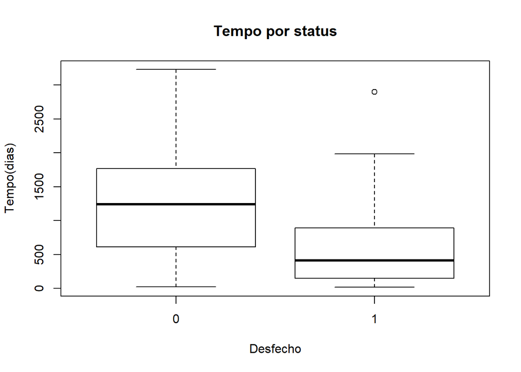

```r
boxplot(
  tempo ~ status,
  data = ipec,
  main = "Tempo por status",
  ylab = "Tempo(dias)",
  xlab = "Desfecho")
```

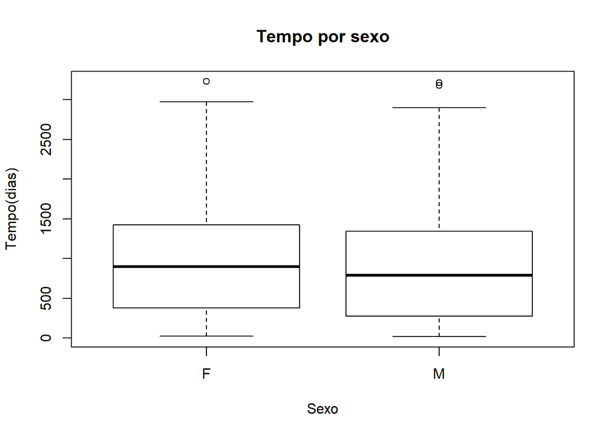

```r
boxplot(
  tempo ~ sexo,
  data = ipec,
  main = "Tempo por sexo",
  ylab = "Tempo(dias)",
  xlab = "Sexo")
```